# Faire Direct Analytics Case

**Problem:** The number of new retailers that place their first confirmed order has gone down.

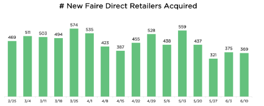

**Goal:** Investigate cause of this decline  
Questions  
• What are some of your hypotheses about the underlying cause of this decline?  
• What are some product ideas you have about how to bring this number back up?

**Hypothesis - What are the possible causes**  
Awareness Stage Issue

The overall new leads(retailers) clicks have declined  
Consideration Stage Issue

New Retailers might be facing difficulty in deciding if they want to try new line items  
Acquisition Stage Issue

The overall conversion rate on Brands Faire Direct Sign-up Page page might have declined

Order confirmation rates might have declined

You don’t have enough leads coming at the top of your current funnel. Your website is getting a lot of visitors, but many of them aren’t converting into customers. You have plenty of users who sign up for free trials, but many of them aren’t converting into paying customers.

# 1) Importing Data

```python
# Importing necessary libraries
import numpy as np
import pandas as pd
import pandasql as ps
import datetime as dt
from datetime import datetime, timedelta
import matplotlib.pyplot as plt
import seaborn as sns

import warnings
warnings.simplefilter(action='ignore', category=FutureWarning)
```

```python
# reading dataset
df = pd.read_csv('elevate_analytics_case_data.csv')
df.head()
```

|  | brand_id | retailer_id | brand_relationship_id | brand_relationship_created_at | brand_relationship_confirmed_at | confirmation_reason | normalized_referer | outgoing_email_id | email_sent_at | brand_relationship_order_id | ... | retailer_placed_first_order_at | retailer_placed_first_confirmed_order_at | power_retailer_converted_at | retailer_gmv | retailer_business_type | brand_stockist_count | brand_first_active_at | brand_adopted_elevate_at | power_maker_converted_at | account_owner |
| --- | --- | --- | --- | --- | --- | --- | --- | --- | --- | --- | --- | --- | --- | --- | --- | --- | --- | --- | --- | --- | --- |
| 0 | 20940 | NaN | 262526 | 2019-06-16 23:59:30 | NaN | NaN | NaN | NaN | NaN | NaN | ... | NaN | NaN | NaN | NaN | NaN | 25.0 | 2019-01-25 21:45:55 | 2019-03-04 21:25:06 | 2019-05-31 16:56:31 | Maker Success |
| 1 | 20940 | NaN | 262525 | 2019-06-16 23:58:26 | NaN | NaN | NaN | NaN | NaN | NaN | ... | NaN | NaN | NaN | NaN | NaN | 25.0 | 2019-01-25 21:45:55 | 2019-03-04 21:25:06 | 2019-05-31 16:56:31 | Maker Success |
| 2 | 19207 | NaN | 262524 | 2019-06-16 23:58:08 | NaN | NaN | Other | NaN | NaN | NaN | ... | NaN | NaN | NaN | NaN | NaN | 50.0 | 2019-01-17 21:43:18 | 2019-01-20 01:48:27 | 2019-04-30 22:18:38 | Maker Success |
| 3 | 20940 | NaN | 262523 | 2019-06-16 23:47:47 | NaN | NaN | NaN | NaN | NaN | NaN | ... | NaN | NaN | NaN | NaN | NaN | 25.0 | 2019-01-25 21:45:55 | 2019-03-04 21:25:06 | 2019-05-31 16:56:31 | Maker Success |
| 4 | 20940 | NaN | 262522 | 2019-06-16 23:46:54 | NaN | NaN | NaN | NaN | NaN | NaN | ... | NaN | NaN | NaN | NaN | NaN | 25.0 | 2019-01-25 21:45:55 | 2019-03-04 21:25:06 | 2019-05-31 16:56:31 | Maker Success |

5 rows × 21 columns

# 2) Transforming data

```python
# converting data types

# from object to date

df[['brand_relationship_confirmed_at',
        'brand_relationship_created_at',
        'retailer_signed_up_at',
        'retailer_placed_first_order_at',
        'retailer_placed_first_confirmed_order_at',
        'brand_first_active_at',
        'email_sent_at',
        'brand_adopted_elevate_at']] = df[['brand_relationship_confirmed_at',
                                               'brand_relationship_created_at',
                                                'retailer_signed_up_at',
                                                'retailer_placed_first_order_at',
                                                'retailer_placed_first_confirmed_order_at',
                                                'brand_first_active_at',
                                                'email_sent_at',
                                                'brand_adopted_elevate_at']].apply(pd.to_datetime)

# from datetime to date

df[['brand_relationship_confirmed_at',
        'brand_relationship_created_at',
        'retailer_signed_up_at',
        'retailer_placed_first_order_at',
        'retailer_placed_first_confirmed_order_at',
        'brand_first_active_at',
        'email_sent_at',
        'brand_adopted_elevate_at']] = df[['brand_relationship_confirmed_at',
                                               'brand_relationship_created_at',
                                                'retailer_signed_up_at',
                                                'retailer_placed_first_order_at',
                                                'retailer_placed_first_confirmed_order_at',
                                                'brand_first_active_at',
                                                'email_sent_at',
                                                'brand_adopted_elevate_at']].apply(lambda t: t.dt.floor('d'))
```

```python
#Power maker
df['power_retailer_flag'] = np.where(df['power_retailer_converted_at'].isnull() == False, 'yes', 'no')
```

```python
df['power_retailer_flag'].value_counts()
```

```
no     215167
yes      3371
Name: power_retailer_flag, dtype: int64
```

```python
df.retailer_id.nunique()
```

```
32873
```

```python
# get only uniqque retailer id
df1 = df.query("power_retailer_flag == 'yes'")
df1.shape[0]
```

```
3371
```

```python
df.retailer_id.nunique()
```

```
32873
```

```python
df1.retailer_id.nunique()
```

```
3363
```

```python
df1.retailer_id.nunique()/df.retailer_id.nunique() * 100
```

```
10.230280169135765
```

#### Out of all the total retailers(32873), only 10% (3363) comprise of power retailers. (GTM: we need to increase this number)**

```python
#email sent
#internal | external

df['email_flag'] = np.where(df['outgoing_email_id'].isnull() == False, 'internal','external' )
df['email_flag'].value_counts()
```

```
external    159380
internal     59158
Name: email_flag, dtype: int64
```

```python
df.head()
#"Enterprise Maker" are accounts managed by the Enterprise team and have at least >500 stockists.
#"Maker Success" are managed by our success team and focus on brands with >50 stockists.
#"Control" is a control group for Maker Success.
#"Small maker or other" are all of the other brands that are not actively managed by one of our team's or in the control.
```

|  | brand_id | retailer_id | brand_relationship_id | brand_relationship_created_at | brand_relationship_confirmed_at | confirmation_reason | normalized_referer | outgoing_email_id | email_sent_at | brand_relationship_order_id | ... | power_retailer_converted_at | retailer_gmv | retailer_business_type | brand_stockist_count | brand_first_active_at | brand_adopted_elevate_at | power_maker_converted_at | account_owner | power_retailer_flag | email_flag |
| --- | --- | --- | --- | --- | --- | --- | --- | --- | --- | --- | --- | --- | --- | --- | --- | --- | --- | --- | --- | --- | --- |
| 0 | 20940 | NaN | 262526 | 2019-06-16 | NaT | NaN | NaN | NaN | NaT | NaN | ... | NaN | NaN | NaN | 25.0 | 2019-01-25 | 2019-03-04 | 2019-05-31 16:56:31 | Maker Success | no | external |
| 1 | 20940 | NaN | 262525 | 2019-06-16 | NaT | NaN | NaN | NaN | NaT | NaN | ... | NaN | NaN | NaN | 25.0 | 2019-01-25 | 2019-03-04 | 2019-05-31 16:56:31 | Maker Success | no | external |
| 2 | 19207 | NaN | 262524 | 2019-06-16 | NaT | NaN | Other | NaN | NaT | NaN | ... | NaN | NaN | NaN | 50.0 | 2019-01-17 | 2019-01-20 | 2019-04-30 22:18:38 | Maker Success | no | external |
| 3 | 20940 | NaN | 262523 | 2019-06-16 | NaT | NaN | NaN | NaN | NaT | NaN | ... | NaN | NaN | NaN | 25.0 | 2019-01-25 | 2019-03-04 | 2019-05-31 16:56:31 | Maker Success | no | external |
| 4 | 20940 | NaN | 262522 | 2019-06-16 | NaT | NaN | NaN | NaN | NaT | NaN | ... | NaN | NaN | NaN | 25.0 | 2019-01-25 | 2019-03-04 | 2019-05-31 16:56:31 | Maker Success | no | external |

5 rows × 23 columns

### 3) Reusable Functions

```python
# Reusable function to get week start date
def week_start_date(datetime):
    return datetime.date() - timedelta(days=datetime.date().weekday())

# direction to use: faire_direct['brand_adopted_elevate_at'].apply(week_start_date)
```

### I am looking at only those new retailer leads where the confirmation reason for joining Faire is through Faire Direct

```python
# filtering
faire_direct = df.loc[(df['confirmation_reason'] == 'SIGNED_UP') | (df['confirmation_reason'] == 'FIRST_ORDER_FOR_BRAND')]
faire_direct['confirmation_reason'].unique()
```

```
array(['SIGNED_UP', 'FIRST_ORDER_FOR_BRAND'], dtype=object)
```

```python
faire_direct.retailer_id.nunique()
```

```
32873
```

```python
faire_direct.head()
```

|  | brand_id | retailer_id | brand_relationship_id | brand_relationship_created_at | brand_relationship_confirmed_at | confirmation_reason | normalized_referer | outgoing_email_id | email_sent_at | brand_relationship_order_id | ... | power_retailer_converted_at | retailer_gmv | retailer_business_type | brand_stockist_count | brand_first_active_at | brand_adopted_elevate_at | power_maker_converted_at | account_owner | power_retailer_flag | email_flag |
| --- | --- | --- | --- | --- | --- | --- | --- | --- | --- | --- | --- | --- | --- | --- | --- | --- | --- | --- | --- | --- | --- |
| 14 | 5663 | 145941.0 | 262510 | 2019-06-16 | 2019-06-16 | SIGNED_UP | Other | NaN | NaT | NaN | ... | NaN | 0.0 | Online Only | NaN | 2018-03-14 | 2018-08-07 | 2018-11-01 04:02:03 | Control | no | external |
| 28 | 26821 | 145936.0 | 262495 | 2019-06-16 | 2019-06-16 | SIGNED_UP | NaN | NaN | NaT | NaN | ... | NaN | 312.0 | Brick & Mortar Store | 100.0 | 2019-05-15 | 2019-05-29 | NaN | Maker Success | no | external |
| 31 | 17454 | 145934.0 | 262492 | 2019-06-16 | 2019-06-16 | SIGNED_UP | brand_website | NaN | NaT | NaN | ... | NaN | 0.0 | Online Only | 50.0 | 2018-12-13 | 2019-01-05 | 2019-02-16 04:19:38 | Maker Success | no | external |
| 45 | 5072 | 145929.0 | 262478 | 2019-06-16 | 2019-06-16 | SIGNED_UP | Other | NaN | NaT | NaN | ... | NaN | 480.0 | Brick & Mortar Store | NaN | 2019-03-28 | 2019-03-28 | 2019-04-01 16:00:51 | Maker Success | no | external |
| 63 | 13695 | 145923.0 | 262457 | 2019-06-16 | 2019-06-16 | SIGNED_UP | Other | -5.237419e+18 | 2019-05-15 | NaN | ... | NaN | 0.0 | We are a special event/decor company. We spec... | 5000.0 | 2018-09-23 | 2019-05-14 | 2019-05-15 15:45:26 | Maker Success | no | internal |

5 rows × 23 columns

# 4) Acquisition Funnel

From the promt, we can see that Faire Direct Acquisition strategy is loosing new retailers, so now we need to identify blockage points in Acquisition Funnel

```python
df = pd.read_csv("elevate_analytics_case_data.csv")
df.head()
```

|  | brand_id | retailer_id | brand_relationship_id | brand_relationship_created_at | brand_relationship_confirmed_at | confirmation_reason | normalized_referer | outgoing_email_id | email_sent_at | brand_relationship_order_id | ... | retailer_placed_first_order_at | retailer_placed_first_confirmed_order_at | power_retailer_converted_at | retailer_gmv | retailer_business_type | brand_stockist_count | brand_first_active_at | brand_adopted_elevate_at | power_maker_converted_at | account_owner |
| --- | --- | --- | --- | --- | --- | --- | --- | --- | --- | --- | --- | --- | --- | --- | --- | --- | --- | --- | --- | --- | --- |
| 0 | 20940 | NaN | 262526 | 2019-06-16 23:59:30 | NaN | NaN | NaN | NaN | NaN | NaN | ... | NaN | NaN | NaN | NaN | NaN | 25.0 | 2019-01-25 21:45:55 | 2019-03-04 21:25:06 | 2019-05-31 16:56:31 | Maker Success |
| 1 | 20940 | NaN | 262525 | 2019-06-16 23:58:26 | NaN | NaN | NaN | NaN | NaN | NaN | ... | NaN | NaN | NaN | NaN | NaN | 25.0 | 2019-01-25 21:45:55 | 2019-03-04 21:25:06 | 2019-05-31 16:56:31 | Maker Success |
| 2 | 19207 | NaN | 262524 | 2019-06-16 23:58:08 | NaN | NaN | Other | NaN | NaN | NaN | ... | NaN | NaN | NaN | NaN | NaN | 50.0 | 2019-01-17 21:43:18 | 2019-01-20 01:48:27 | 2019-04-30 22:18:38 | Maker Success |
| 3 | 20940 | NaN | 262523 | 2019-06-16 23:47:47 | NaN | NaN | NaN | NaN | NaN | NaN | ... | NaN | NaN | NaN | NaN | NaN | 25.0 | 2019-01-25 21:45:55 | 2019-03-04 21:25:06 | 2019-05-31 16:56:31 | Maker Success |
| 4 | 20940 | NaN | 262522 | 2019-06-16 23:46:54 | NaN | NaN | NaN | NaN | NaN | NaN | ... | NaN | NaN | NaN | NaN | NaN | 25.0 | 2019-01-25 21:45:55 | 2019-03-04 21:25:06 | 2019-05-31 16:56:31 | Maker Success |

5 rows × 21 columns

```python
df_req = df[['brand_id', 'retailer_id', 'brand_relationship_id', 'brand_relationship_created_at', 'brand_relationship_confirmed_at', 'confirmation_reason',
            'normalized_referer', 'retailer_signed_up_at', 'retailer_placed_first_order_at',
            'retailer_placed_first_confirmed_order_at','email_sent_at','power_retailer_converted_at', 'retailer_business_type', 'brand_stockist_count',
            'brand_first_active_at', 'brand_adopted_elevate_at', 'account_owner']]
```

```python
# converting data types

# from object to date

df_req[['brand_relationship_confirmed_at',
        'brand_relationship_created_at',
        'retailer_signed_up_at',
        'retailer_placed_first_order_at',
        'retailer_placed_first_confirmed_order_at',
        'email_sent_at',
        'power_retailer_converted_at',
        'brand_first_active_at',
        'brand_adopted_elevate_at']] = df_req[['brand_relationship_confirmed_at',
                                               'brand_relationship_created_at',
                                                'retailer_signed_up_at',
                                                'retailer_placed_first_order_at',
                                                'retailer_placed_first_confirmed_order_at',
                                                'email_sent_at',
                                                'power_retailer_converted_at',
                                                'brand_first_active_at',
                                                'brand_adopted_elevate_at']].apply(pd.to_datetime)

# from datetime to date

df_req[['brand_relationship_confirmed_at',
        'brand_relationship_created_at',
        'retailer_signed_up_at',
        'retailer_placed_first_order_at',
        'retailer_placed_first_confirmed_order_at',
        'email_sent_at',
        'power_retailer_converted_at',
        'brand_first_active_at',
        'brand_adopted_elevate_at']] = df_req[['brand_relationship_confirmed_at',
                                               'brand_relationship_created_at',
                                                'retailer_signed_up_at',
                                                'retailer_placed_first_order_at',
                                                'retailer_placed_first_confirmed_order_at',
                                                'email_sent_at',
                                                'power_retailer_converted_at',
                                                'brand_first_active_at',
                                                'brand_adopted_elevate_at']].apply(lambda t: t.dt.floor('d'))
```

### Journey from order placed to order confirmed

```python
df_acquired_retailers = df_req.query('confirmation_reason == "SIGNED_UP" or confirmation_reason == "FIRST_ORDER_FOR_BRAND"')
df_acquired_retailers = df_acquired_retailers.loc[(df_acquired_retailers['retailer_placed_first_confirmed_order_at']
                                                   < '2019-06-17') &
                              (df_acquired_retailers['retailer_placed_first_confirmed_order_at'] >= '2019-02-25')]
```

```python
df_acquired_retailers.retailer_id.nunique()
```

```
7378
```

### Journey from signing up to placing order

```python
df_placed_orders = pd.merge(df_acquired_retailers, df_req, on='retailer_placed_first_confirmed_order_at', how='inner')
```

```python
df_placed_orders.retailer_placed_first_order_at_y.min(), df_placed_orders.retailer_placed_first_order_at_y.max()
```

```
(Timestamp('2018-08-16 00:00:00'), Timestamp('2019-06-16 00:00:00'))
```

```python
df_placed_orders_acq = df_req.query('confirmation_reason == "SIGNED_UP" or confirmation_reason == "FIRST_ORDER_FOR_BRAND"')
df_placed_orders_acq = df_placed_orders_acq.loc[(df_placed_orders_acq['retailer_placed_first_order_at']
                                                   < '2019-06-17') &
                              (df_placed_orders_acq['retailer_placed_first_order_at'] >= '2018-08-16')]
```

```python
df_placed_orders_acq.retailer_id.nunique()
```

```
15389
```

### Journey from relationship created (click) to sign - up

```python
df_signups = pd.merge(df_acquired_retailers, df_req, on='retailer_placed_first_confirmed_order_at', how='inner')
```

```python
df_signups.brand_relationship_confirmed_at_y.min(), df_signups.brand_relationship_confirmed_at_y.max()
```

```
(Timestamp('2018-04-27 00:00:00'), Timestamp('2019-06-16 00:00:00'))
```

```python
df_signups_acq = df_req.query('confirmation_reason == "SIGNED_UP" or confirmation_reason == "FIRST_ORDER_FOR_BRAND"')
df_signups_acq = df_signups_acq.loc[(df_signups_acq['brand_relationship_confirmed_at']
                                                   < '2019-06-17') &
                              (df_signups_acq['brand_relationship_confirmed_at'] >= '2018-04-27')]
```

```python
df_signups_acq.retailer_id.nunique()
```

```
32826
```

### Journey at top of the funnel - incoming clicks

```python
df_clicks = pd.merge(df_acquired_retailers, df_req, on='retailer_placed_first_confirmed_order_at', how='inner')
```

```python
df_clicks.brand_relationship_created_at_y.min(), df_clicks.brand_relationship_created_at_y.max()
```

```
(Timestamp('2018-04-27 00:00:00'), Timestamp('2019-06-16 00:00:00'))
```

```python
df_clicks_acq = df_req.query('confirmation_reason == "SIGNED_UP" or confirmation_reason == "FIRST_ORDER_FOR_BRAND"')
df_clicks_acq = df_clicks_acq.loc[(df_clicks_acq['brand_relationship_created_at']
                                                   < '2019-06-17') &
                              (df_clicks_acq['brand_relationship_created_at'] >= '2018-04-27')]
```

```python
df_clicks_acq.retailer_id.nunique()
```

```
32850
```

## 4.1) Funnel Analysis

```python
# creating email flags
df_acquired_retailers['email_flag'] = np.where(df_acquired_retailers['email_sent_at'].isnull() == False, 'sent', 'not sent')
df_acquired_retailers['order_confirmed_week_start'] = df_acquired_retailers['retailer_placed_first_confirmed_order_at'].apply(week_start_date)
```

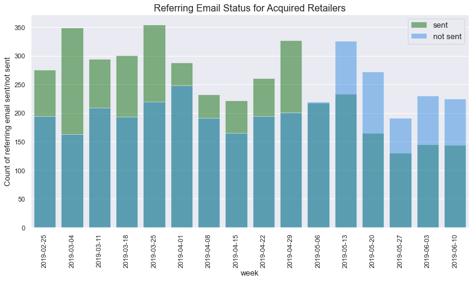

```python
tmp1 = df_acquired_retailers.groupby(['order_confirmed_week_start','email_flag'],as_index=False)['retailer_id'].count().rename(columns = {'retailer_id':'No of Retailers Acquired'})
# visualizing the output
plt.figure(figsize=(13,6.5))
sns.set(style='darkgrid', font_scale=1.2, rc={"lines.linewidth":1.4});
x1 =tmp1.query("email_flag == 'sent'")['order_confirmed_week_start']
y1 =tmp1.query("email_flag == 'sent'")['No of Retailers Acquired']
g = sns.barplot(x1, y1, color= 'green', label = 'sent', alpha = 0.5)

x2 =tmp1.query("email_flag == 'not sent'")['order_confirmed_week_start']
y2 =tmp1.query("email_flag == 'not sent'")['No of Retailers Acquired']
g = sns.barplot(x2, y2, color= 'dodgerblue',label = 'not sent', alpha = 0.5)


g.set_title("Referring Email Status for Acquired Retailers", fontsize = 16)
g.set_xlabel("week", fontsize = 13)
g.set_ylabel("Count of referring email sent/not sent", fontsize = 13)
plt.xticks(rotation=90, fontsize=11)
plt.yticks(fontsize=11)
g.legend();
```

```python
# check difference in brand_relationship_confirmed_at_y & retailer_placed_first_order_at
df_signups_acq['placed_flag'] = np.where(df_signups_acq['retailer_placed_first_order_at'].isnull() == False, 'placed','not_placed' )
```

```python
df_signups_acq['signup_week_start'] = df_signups_acq['brand_relationship_confirmed_at'].apply(week_start_date)
```

```python
tmp1 = df_signups_acq.loc[(df_signups_acq['brand_relationship_created_at']
                                                   < '2019-06-17') &
                              (df_signups_acq['brand_relationship_created_at'] >= '2019-02-25')]
tmp1 = tmp1.groupby(['signup_week_start','placed_flag',],as_index=False)['retailer_id'].count().rename(columns = {'retailer_id':'No of Retailers'})
tmp1.tail(20)
```

|  | signup_week_start | placed_flag | No of Retailers |
| --- | --- | --- | --- |
| 12 | 2019-04-08 | not_placed | 363 |
| 13 | 2019-04-08 | placed | 429 |
| 14 | 2019-04-15 | not_placed | 515 |
| 15 | 2019-04-15 | placed | 453 |
| 16 | 2019-04-22 | not_placed | 612 |
| 17 | 2019-04-22 | placed | 566 |
| 18 | 2019-04-29 | not_placed | 820 |
| 19 | 2019-04-29 | placed | 770 |
| 20 | 2019-05-06 | not_placed | 585 |
| 21 | 2019-05-06 | placed | 509 |
| 22 | 2019-05-13 | not_placed | 850 |
| 23 | 2019-05-13 | placed | 775 |
| 24 | 2019-05-20 | not_placed | 543 |
| 25 | 2019-05-20 | placed | 458 |
| 26 | 2019-05-27 | not_placed | 341 |
| 27 | 2019-05-27 | placed | 319 |
| 28 | 2019-06-03 | not_placed | 410 |
| 29 | 2019-06-03 | placed | 348 |
| 30 | 2019-06-10 | not_placed | 477 |
| 31 | 2019-06-10 | placed | 343 |

```python
'''# visualizing the output
plt.figure(figsize=(13,6.5))

sns.set(style='darkgrid', font_scale=1.2, rc={"lines.linewidth":1.4});

x1 =tmp1.query("placed_flag == 'not placed'")['signup_week_start']
y1 =tmp1.query("placed_flag == 'not placed'")['No of Retailers']
g = sns.barplot(x2, y2, color= 'white',label = 'not placed',  alpha = 1)

x2 =tmp1.query("placed_flag == 'placed'")['signup_week_start']
y2 =tmp1.query("placed_flag == 'placed'")['No of Retailers']
g = sns.barplot(x2, y2, color= 'black',label = 'placed',  alpha = 0.25)


g.set_title("Trend Analysis - Signup vs orders placed", fontsize = 16)
g.set_xlabel("week", fontsize = 13)
g.set_ylabel("Number of Retailers", fontsize = 13)
plt.xticks(rotation=90, fontsize=11)
plt.yticks(fontsize=11)
g.legend();'''
```

[output not shown]

There are lot of retailers who signed up in 2018 but placed their order in 2019. So to understand the decline trend in 2019, we will focus only on the signups from 2019. Below are some of the insights:

In start of 2019, there is 30% decline from 18 Feb and then sudden spike in april as compared to last week of March2019 and first week of April2019.

After that the numbers fluctuated.

May also observed dropping numbers (56% decline for middle of May to 10th of June)

```python
# orders placed to order confirmation analysis

df_placed_orders_acq['order_confirmation_flag'] = np.where(df_placed_orders_acq['retailer_placed_first_confirmed_order_at']
                                                          .isnull() == False, "confirmed", "not confirmed")
```

```python
df_placed_orders_acq['order_placed_week_start'] = df_placed_orders_acq['retailer_placed_first_order_at'].apply(week_start_date)
```

```python
df_placed_orders_acq.to_excel("placed_orders_confirm.xlsx")
```

```python
'''tmp2 = df_placed_orders_acq.loc[(df_placed_orders_acq['brand_relationship_created_at']
                                                   < '2019-06-17') &
                              (df_placed_orders_acq['brand_relationship_created_at'] >= '2019-02-25')]'''
tmp2 = df_placed_orders_acq.groupby(['order_placed_week_start','order_confirmation_flag',],as_index=False)['retailer_id'].count().rename(columns = {'retailer_id':'No of Retailers'})
tmp2.tail(20)
```

|  | order_placed_week_start | order_confirmation_flag | No of Retailers |
| --- | --- | --- | --- |
| 66 | 2019-04-08 | confirmed | 420 |
| 67 | 2019-04-08 | not confirmed | 79 |
| 68 | 2019-04-15 | confirmed | 383 |
| 69 | 2019-04-15 | not confirmed | 110 |
| 70 | 2019-04-22 | confirmed | 457 |
| 71 | 2019-04-22 | not confirmed | 150 |
| 72 | 2019-04-29 | confirmed | 529 |
| 73 | 2019-04-29 | not confirmed | 272 |
| 74 | 2019-05-06 | confirmed | 431 |
| 75 | 2019-05-06 | not confirmed | 129 |
| 76 | 2019-05-13 | confirmed | 557 |
| 77 | 2019-05-13 | not confirmed | 302 |
| 78 | 2019-05-20 | confirmed | 435 |
| 79 | 2019-05-20 | not confirmed | 94 |
| 80 | 2019-05-27 | confirmed | 321 |
| 81 | 2019-05-27 | not confirmed | 89 |
| 82 | 2019-06-03 | confirmed | 372 |
| 83 | 2019-06-03 | not confirmed | 86 |
| 84 | 2019-06-10 | confirmed | 361 |
| 85 | 2019-06-10 | not confirmed | 124 |

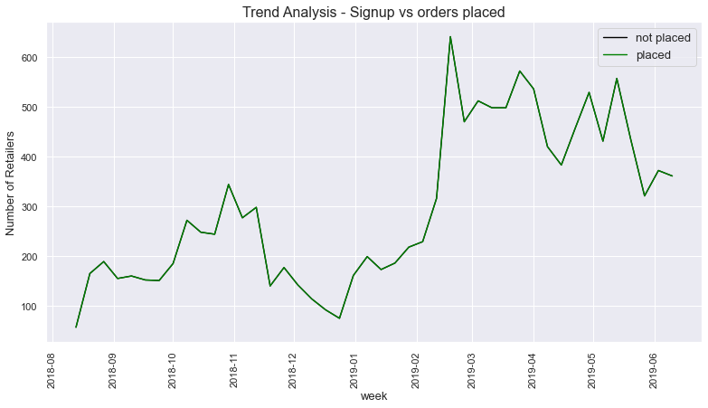

```python
# visualizing the output
plt.figure(figsize=(13,6.5))

sns.set(style='darkgrid', font_scale=1.2, rc={"lines.linewidth":1.4});

x1 =tmp2.query("order_confirmation_flag == 'not confirmed'")['order_placed_week_start']
y1 =tmp2.query("order_confirmation_flag == 'not confirmed'")['No of Retailers']
g = sns.lineplot(x2, y2, color= 'black',label = 'not placed',  alpha = 1)

x2 =tmp2.query("order_confirmation_flag == 'confirmed'")['order_placed_week_start']
y2 =tmp2.query("order_confirmation_flag == 'confirmed'")['No of Retailers']
g = sns.lineplot(x2, y2, color= 'green',label = 'placed',  alpha = 1)


g.set_title("Trend Analysis - Signup vs orders placed", fontsize = 16)
g.set_xlabel("week", fontsize = 13)
g.set_ylabel("Number of Retailers", fontsize = 13)
plt.xticks(rotation=90, fontsize=11)
plt.yticks(fontsize=11)
g.legend();
```

Bottom of the funnel: What is the weekly trend for the number of new retailers that place their first confirmed order that was confirmed by Faire

```python
#Filter data between date range '2019-06-17' and '2019-02-25' date range
faire_direct = faire_direct.loc[(faire_direct['retailer_placed_first_confirmed_order_at'] < '2019-06-17') & (faire_direct['retailer_placed_first_confirmed_order_at'] >= '2019-02-25')]
```

```python
# get week start date for retailer_placed_first_confirmed_order_at
faire_direct['confirmed_first_order_at_week'] = faire_direct['retailer_placed_first_confirmed_order_at'].apply(week_start_date)
# grouping
stage1= faire_direct.groupby('confirmed_first_order_at_week',as_index=False)['retailer_id'].count().rename(columns = {'retailer_id':'No of Retailers Acquired'})
# calculating percent change
stage1['week_over_week_variance_percent'] = stage1['No of Retailers Acquired'].pct_change();
```

```python
stage1
```

|  | confirmed_first_order_at_week | No of Retailers Acquired | week_over_week_variance_percent |
| --- | --- | --- | --- |
| 0 | 2019-02-25 | 469 | NaN |
| 1 | 2019-03-04 | 512 | 0.091684 |
| 2 | 2019-03-11 | 503 | -0.017578 |
| 3 | 2019-03-18 | 494 | -0.017893 |
| 4 | 2019-03-25 | 574 | 0.161943 |
| 5 | 2019-04-01 | 536 | -0.066202 |
| 6 | 2019-04-08 | 423 | -0.210821 |
| 7 | 2019-04-15 | 387 | -0.085106 |
| 8 | 2019-04-22 | 455 | 0.175711 |
| 9 | 2019-04-29 | 528 | 0.160440 |
| 10 | 2019-05-06 | 438 | -0.170455 |
| 11 | 2019-05-13 | 559 | 0.276256 |
| 12 | 2019-05-20 | 437 | -0.218247 |
| 13 | 2019-05-27 | 321 | -0.265446 |
| 14 | 2019-06-03 | 375 | 0.168224 |
| 15 | 2019-06-10 | 369 | -0.016000 |

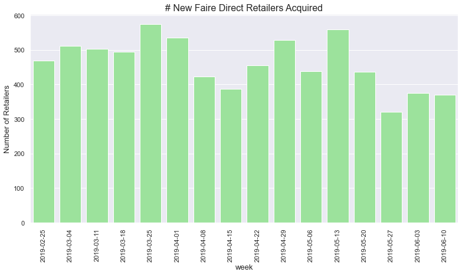

```python
# visualizing the output
plt.figure(figsize=(13,6.5))
sns.set(style='darkgrid', font_scale=1.2)
x = x=stage1['confirmed_first_order_at_week']
y = y=stage1['No of Retailers Acquired']
g = sns.barplot(x, y, color= 'lightgreen')
g.set_title("# New Faire Direct Retailers Acquired", fontsize = 16)
g.set_xlabel("week", fontsize = 13)
g.set_ylabel("Number of Retailers", fontsize = 13)
plt.xticks(rotation=90, fontsize=11)
plt.yticks(fontsize=11);
```

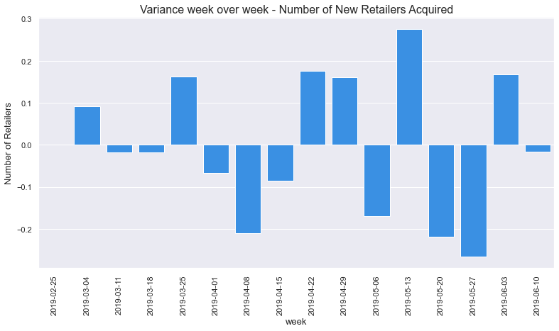

```python
# visualizing the output
plt.figure(figsize=(13,6.5))
sns.set(style='darkgrid', font_scale=1.2)
x = x=stage1['confirmed_first_order_at_week']
y = y=stage1['week_over_week_variance_percent']
g = sns.barplot(x, y, color= 'dodgerblue')
g.set_title("Variance week over week - Number of New Retailers Acquired", fontsize = 16)
g.set_xlabel("week", fontsize = 13)
g.set_ylabel("Number of Retailers", fontsize = 13)
plt.xticks(rotation=90, fontsize=11)
plt.yticks(fontsize=11);
```

**Analyst notes:**

From the acquisition trend, we can see that the number of retailers acquired have dropped.

After March 2019, there is a significant drop in first 3 weeks of April 2019

Although there is a significant rise (28%) in these numbers in second week of May 2019, the numbers again start dropping by 22% and 27% in the last two weeks of May 2019 respectively

There are high chances that the drop initiated from 1st three weeks of April 2019 and then 3rd week of May 2019

```python
# Slicing by retailer and email and team type
# email_flag, account_owner, power_retailer_flag
a = faire_direct.groupby(['confirmed_first_order_at_week','power_retailer_flag'],as_index=False)['brand_id'].count().rename(columns = {'brand_id':'No of Retailers Acquired'})
```

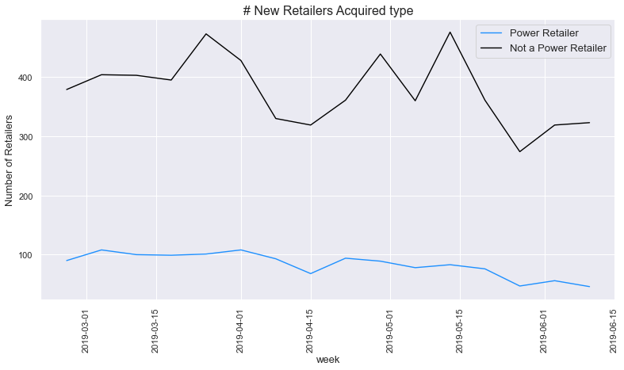

```python
# visualizing the output
plt.figure(figsize=(13,6.5))
sns.set(style='darkgrid', font_scale=1.2, rc={"lines.linewidth":1.4});
x1 =a.query("power_retailer_flag == 'yes'")['confirmed_first_order_at_week']
y1 =a.query("power_retailer_flag == 'yes'")['No of Retailers Acquired']
g = sns.lineplot(x1, y1, color= 'dodgerblue', label = 'Power Retailer')

x2 =a.query("power_retailer_flag == 'no'")['confirmed_first_order_at_week']
y2 =a.query("power_retailer_flag == 'no'")['No of Retailers Acquired']
g = sns.lineplot(x2, y2, color= 'black',label = 'Not a Power Retailer')


g.set_title("# New Retailers Acquired type", fontsize = 16)
g.set_xlabel("week", fontsize = 13)
g.set_ylabel("Number of Retailers", fontsize = 13)
plt.xticks(rotation=90, fontsize=11)
plt.yticks(fontsize=11)
g.legend();
```

### Lets go one step back to see if number of orders placed have similar heavy drop in April2019 and May2019

```python
# filtering date range
faire_direct = faire_direct.loc[(faire_direct['retailer_placed_first_order_at'] < '2019-06-17') & (faire_direct['retailer_placed_first_order_at'] >= '2019-02-25')]
```

```python
# get week start date
faire_direct['order_placed_at_week'] = faire_direct['retailer_placed_first_order_at'].apply(week_start_date)
# grouping
stage2 =  faire_direct.groupby('order_placed_at_week',as_index=False)['brand_id'].count().rename(columns = {'brand_id':'No of Retailers'})
# calculating percent change
stage2['week_over_week_variance_percent'] = stage2['No of Retailers'].pct_change();
```

```python
# convert to date datatype
#faire_direct['order_placed_at_week'] = faire_direct['order_placed_at_week'].apply(pd.to_datetime)
```

```python
stage2.head()
```

|  | order_placed_at_week | No of Retailers | week_over_week_variance_percent |
| --- | --- | --- | --- |
| 0 | 2019-02-25 | 470 | NaN |
| 1 | 2019-03-04 | 512 | 0.089362 |
| 2 | 2019-03-11 | 498 | -0.027344 |
| 3 | 2019-03-18 | 498 | 0.000000 |
| 4 | 2019-03-25 | 572 | 0.148594 |

```python
stage2['No of Retailers'].sum()
```

```
7346
```

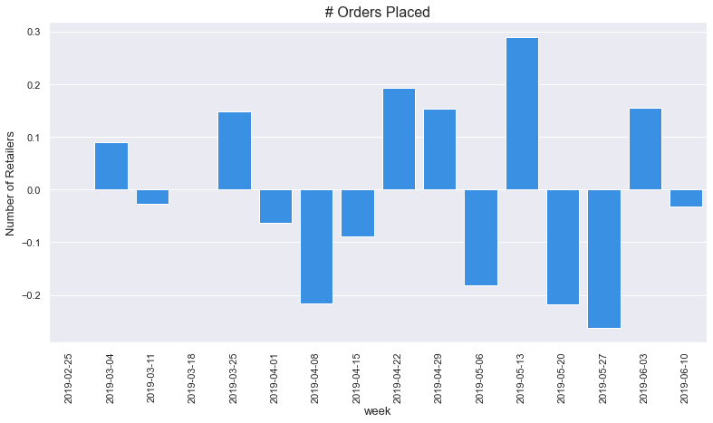

```python
# visualizing the output
plt.figure(figsize=(13,6.5))
sns.set(style='darkgrid', font_scale=1.2)
x = x=stage2['order_placed_at_week']
y = y=stage2['week_over_week_variance_percent']
g = sns.barplot(x, y, color= 'dodgerblue')
g.set_title("# Orders Placed", fontsize = 16)
g.set_xlabel("week", fontsize = 13)
g.set_ylabel("Number of Retailers", fontsize = 13)
plt.xticks(rotation=90, fontsize=11)
plt.yticks(fontsize=11);
```

### Lets go one step back to see if signups have similar heavy drop in April2019 and May2019

```python
# filtering date range
faire_direct = faire_direct.loc[(faire_direct['brand_relationship_confirmed_at'] < '2019-06-17') & (faire_direct['brand_relationship_confirmed_at'] >= '2019-02-25')]
```

```python
# get week start date
faire_direct['sign_up_at_week'] = faire_direct['brand_relationship_confirmed_at'].apply(week_start_date)
# grouping
stage3 =  faire_direct.groupby('sign_up_at_week',as_index=False)['brand_id'].count().rename(columns = {'brand_id':'No of Retailers'})
# calculating percent change
stage3['week_over_week_variance_percent'] = stage3['No of Retailers'].pct_change();
```

```python
stage3
```

|  | sign_up_at_week | No of Retailers | week_over_week_variance_percent |
| --- | --- | --- | --- |
| 0 | 2019-02-25 | 427 | NaN |
| 1 | 2019-03-04 | 441 | 0.032787 |
| 2 | 2019-03-11 | 452 | 0.024943 |
| 3 | 2019-03-18 | 461 | 0.019912 |
| 4 | 2019-03-25 | 561 | 0.216920 |
| 5 | 2019-04-01 | 837 | 0.491979 |
| 6 | 2019-04-08 | 354 | -0.577061 |
| 7 | 2019-04-15 | 341 | -0.036723 |
| 8 | 2019-04-22 | 413 | 0.211144 |
| 9 | 2019-04-29 | 488 | 0.181598 |
| 10 | 2019-05-06 | 390 | -0.200820 |
| 11 | 2019-05-13 | 461 | 0.182051 |
| 12 | 2019-05-20 | 364 | -0.210412 |
| 13 | 2019-05-27 | 240 | -0.340659 |
| 14 | 2019-06-03 | 256 | 0.066667 |
| 15 | 2019-06-10 | 215 | -0.160156 |

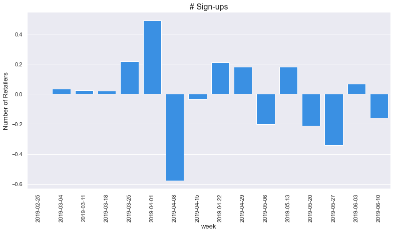

```python
# visualizing the output
plt.figure(figsize=(13,6.5))
sns.set(style='darkgrid', font_scale=1.2)
x = stage3['sign_up_at_week']
y = stage3['week_over_week_variance_percent']
g = sns.barplot(x, y, color= 'dodgerblue')
g.set_title("# Sign-ups", fontsize = 16)
g.set_xlabel("week", fontsize = 13)
g.set_ylabel("Number of Retailers", fontsize = 13)
plt.xticks(rotation=90, fontsize=11)
plt.yticks(fontsize=11);
```

```python
stage3['No of Retailers'].sum()
```

```
6701
```

```python
# filtering date range
faire_direct = faire_direct.loc[(faire_direct['brand_relationship_created_at'] < '2019-06-17') & (faire_direct['brand_relationship_created_at'] >= '2019-02-25')]
```

```python
faire_direct.retailer_id.nunique()
```

```
6630
```

```python
# get week start date
faire_direct['clicks_at_week'] = faire_direct['brand_relationship_created_at'].apply(week_start_date)
# grouping
stage4 =  faire_direct.groupby('clicks_at_week',as_index=False)['retailer_id'].count().rename(columns = {'retailer_id':'No of Retailers'})
# calculating percent change
stage4['week_over_week_variance_percent'] = stage4['No of Retailers'].pct_change();
```

```python
stage4
```

|  | clicks_at_week | No of Retailers | week_over_week_variance_percent |
| --- | --- | --- | --- |
| 0 | 2019-02-25 | 481 | NaN |
| 1 | 2019-03-04 | 523 | 0.087318 |
| 2 | 2019-03-11 | 504 | -0.036329 |
| 3 | 2019-03-18 | 489 | -0.029762 |
| 4 | 2019-03-25 | 559 | 0.143149 |
| 5 | 2019-04-01 | 581 | 0.039356 |
| 6 | 2019-04-08 | 348 | -0.401033 |
| 7 | 2019-04-15 | 335 | -0.037356 |
| 8 | 2019-04-22 | 419 | 0.250746 |
| 9 | 2019-04-29 | 488 | 0.164678 |
| 10 | 2019-05-06 | 379 | -0.223361 |
| 11 | 2019-05-13 | 467 | 0.232190 |
| 12 | 2019-05-20 | 361 | -0.226981 |
| 13 | 2019-05-27 | 235 | -0.349030 |
| 14 | 2019-06-03 | 254 | 0.080851 |
| 15 | 2019-06-10 | 207 | -0.185039 |

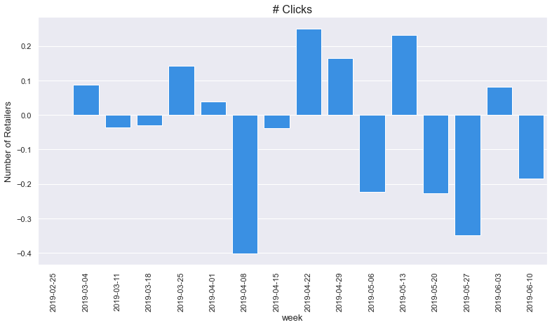

```python
# visualizing the output
plt.figure(figsize=(13,6.5))
sns.set(style='darkgrid', font_scale=1.2)
x = stage4['clicks_at_week']
y = stage4['week_over_week_variance_percent']
g = sns.barplot(x, y, color= 'dodgerblue')
g.set_title("# Clicks", fontsize = 16)
g.set_xlabel("week", fontsize = 13)
g.set_ylabel("Number of Retailers", fontsize = 13)
plt.xticks(rotation=90, fontsize=11)
plt.yticks(fontsize=11);
```

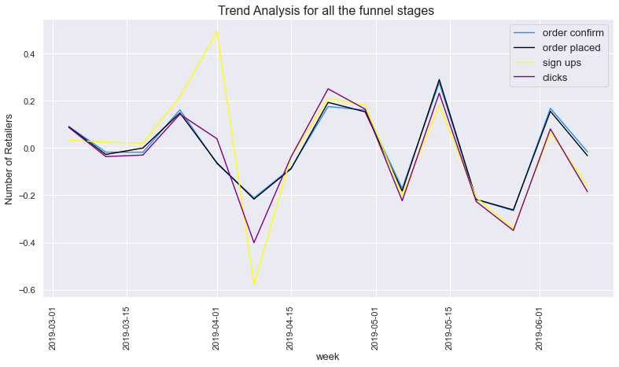

```python
# visualizing the output
plt.figure(figsize=(13,6.5))
sns.set(style='darkgrid', font_scale=1.2, rc={"lines.linewidth":1.4});
x1 =stage1['confirmed_first_order_at_week']
y1 =stage1['week_over_week_variance_percent']
g = sns.lineplot(x1, y1, color= 'dodgerblue', label = 'order confirm')

x2 =stage2['order_placed_at_week']
y2 =stage2['week_over_week_variance_percent']
g = sns.lineplot(x2, y2, color= 'black',label = 'order placed')


x3 =stage3['sign_up_at_week']
y3 =stage3['week_over_week_variance_percent']
g = sns.lineplot(x3, y3, color= 'yellow',label = 'sign ups')

x4 =stage4['clicks_at_week']
y4 =stage4['week_over_week_variance_percent']
g = sns.lineplot(x4, y4, color= 'purple',label = 'clicks')

g.set_title("Trend Analysis for all the funnel stages ", fontsize = 16)
g.set_xlabel("week", fontsize = 13)
g.set_ylabel("Number of Retailers", fontsize = 13)
plt.xticks(rotation=90, fontsize=11)
plt.yticks(fontsize=11)
g.legend();
```

**Analyst notes:** The overall New Retailers by the Faire Direct Strategy have declined

From the awareness trend, we can see that the number of visitors on all Brand's Faire Direct Page have dropped.

There are high chances that the drop initiated from 1st three weeks of April 2019 and then 3rd week of May 2019

### Determine where does high quality visitors come from?

```python
faire_direct.head()
```

|  | brand_id | retailer_id | brand_relationship_id | brand_relationship_created_at | brand_relationship_confirmed_at | confirmation_reason | normalized_referer | outgoing_email_id | email_sent_at | brand_relationship_order_id | ... | brand_first_active_at | brand_adopted_elevate_at | power_maker_converted_at | account_owner | power_retailer_flag | email_flag | confirmed_first_order_at_week | order_placed_at_week | sign_up_at_week | clicks_at_week |
| --- | --- | --- | --- | --- | --- | --- | --- | --- | --- | --- | --- | --- | --- | --- | --- | --- | --- | --- | --- | --- | --- |
| 45 | 5072 | 145929.0 | 262478 | 2019-06-16 | 2019-06-16 | SIGNED_UP | Other | NaN | NaT | NaN | ... | 2019-03-28 | 2019-03-28 | 2019-04-01 16:00:51 | Maker Success | no | external | 2019-06-10 | 2019-06-10 | 2019-06-10 | 2019-06-10 |
| 71 | 9390 | 145919.0 | 262446 | 2019-06-16 | 2019-06-16 | SIGNED_UP | brand_website | NaN | NaT | NaN | ... | 2018-11-19 | 2018-12-04 | NaN | Maker Success | no | external | 2019-06-10 | 2019-06-10 | 2019-06-10 | 2019-06-10 |
| 151 | 17742 | 145897.0 | 262362 | 2019-06-16 | 2019-06-16 | SIGNED_UP | Other | NaN | NaT | NaN | ... | 2019-05-09 | 2019-05-09 | 2019-05-13 17:00:24 | Maker Success | no | external | 2019-06-10 | 2019-06-10 | 2019-06-10 | 2019-06-10 |
| 353 | 14379 | 145824.0 | 262153 | 2019-06-16 | 2019-06-16 | SIGNED_UP | Other | 6.586548e+18 | 2019-06-16 | NaN | ... | 2018-10-22 | 2018-10-31 | 2018-12-18 17:08:11 | Maker Success | no | internal | 2019-06-10 | 2019-06-10 | 2019-06-10 | 2019-06-10 |
| 398 | 28795 | 145797.0 | 262090 | 2019-06-16 | 2019-06-16 | SIGNED_UP | NaN | NaN | NaT | NaN | ... | 2019-06-14 | 2019-06-15 | NaN | Small maker or other | no | external | 2019-06-10 | 2019-06-10 | 2019-06-10 | 2019-06-10 |

5 rows × 27 columns

```python
faire_direct_email = faire_direct.loc[(faire_direct['retailer_placed_first_confirmed_order_at'] < '2019-06-17') &
                              (faire_direct['retailer_placed_first_confirmed_order_at'] >= '2019-02-25')]
```

```python
faire_direct_email.retailer_id.nunique()
```

```
6630
```

```python
# brand ke page pe kaise aa sakte hai?
#faire_direct.['brand_relationship_id']
# sabse pehle email bheja aur uske baad referer
faire_direct.query('email_flag == "internal"').normalized_referer.unique()
```

```
array(['Other', nan, 'brand_website'], dtype=object)
```

So basically, the retailers who clicked on the link

```python
# lets only see channels where most of new retailers came
stage4.query('week_over_week_variance_percent > 0 ')
```

|  | clicks_at_week | No of Retailers | week_over_week_variance_percent |
| --- | --- | --- | --- |
| 1 | 2019-03-04 | 523 | 0.087318 |
| 4 | 2019-03-25 | 559 | 0.143149 |
| 5 | 2019-04-01 | 581 | 0.039356 |
| 8 | 2019-04-22 | 419 | 0.250746 |
| 9 | 2019-04-29 | 488 | 0.164678 |
| 11 | 2019-05-13 | 467 | 0.232190 |
| 14 | 2019-06-03 | 254 | 0.080851 |

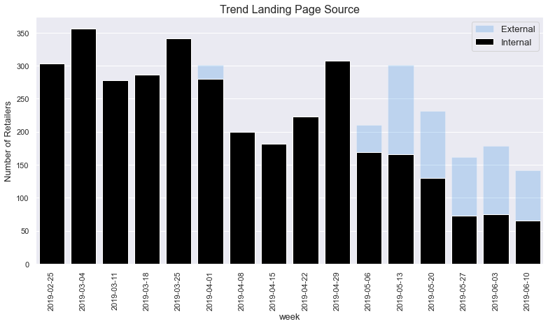

```python
tmp1 = pd.merge(stage4,faire_direct, on =['clicks_at_week'], how='inner')
tmp1 = tmp1.groupby(['clicks_at_week','email_flag'],as_index=False)['brand_id'].count().rename(columns = {'brand_id':'No of Retailers Acquired'})
# visualizing the output
plt.figure(figsize=(13,6.5))
sns.set(style='darkgrid', font_scale=1.2, rc={"lines.linewidth":1.4});
x1 =tmp1.query("email_flag == 'external'")['clicks_at_week']
y1 =tmp1.query("email_flag == 'external'")['No of Retailers Acquired']
g = sns.barplot(x1, y1, color= 'dodgerblue', label = 'External', alpha = 0.25)

x2 =tmp1.query("email_flag == 'internal'")['clicks_at_week']
y2 =tmp1.query("email_flag == 'internal'")['No of Retailers Acquired']
g = sns.barplot(x2, y2, color= 'black',label = 'Internal')


g.set_title("Trend Landing Page Source", fontsize = 16)
g.set_xlabel("week", fontsize = 13)
g.set_ylabel("Number of Retailers", fontsize = 13)
plt.xticks(rotation=90, fontsize=11)
plt.yticks(fontsize=11)
g.legend();
```

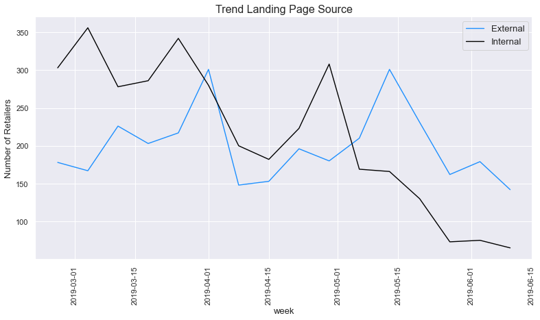

```python
# visualizing the output
plt.figure(figsize=(13,6.5))
sns.set(style='darkgrid', font_scale=1.2, rc={"lines.linewidth":1.4});
x1 =tmp1.query("email_flag == 'external'")['clicks_at_week']
y1 =tmp1.query("email_flag == 'external'")['No of Retailers Acquired']
g = sns.lineplot(x1, y1, color= 'dodgerblue', label = 'External')

x2 =tmp1.query("email_flag == 'internal'")['clicks_at_week']
y2 =tmp1.query("email_flag == 'internal'")['No of Retailers Acquired']
g = sns.lineplot(x2, y2, color= 'black',label = 'Internal')


g.set_title("Trend Landing Page Source", fontsize = 16)
g.set_xlabel("week", fontsize = 13)
g.set_ylabel("Number of Retailers", fontsize = 13)
plt.xticks(rotation=90, fontsize=11)
plt.yticks(fontsize=11)
g.legend();
```

### Which teams are affected?

```python
team = df_acquired_retailers.groupby(['order_confirmed_week_start','account_owner'])['retailer_id'].count().reset_index()
team.rename(columns = {'retailer_id':'No of Retailers Acquired'}, inplace=True)
```

```python
team.head()
```

|  | order_confirmed_week_start | account_owner | No of Retailers Acquired |
| --- | --- | --- | --- |
| 0 | 2019-02-25 | Control | 11 |
| 1 | 2019-02-25 | Enterprise Maker | 13 |
| 2 | 2019-02-25 | Maker Success | 403 |
| 3 | 2019-02-25 | Small maker or other | 42 |
| 4 | 2019-03-04 | Control | 17 |

```python
team.account_owner.unique()
```

```
array(['Control', 'Enterprise Maker', 'Maker Success',
       'Small maker or other'], dtype=object)
```

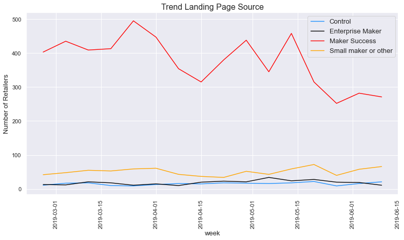

```python
# visualizing the output
plt.figure(figsize=(13,6.5))
sns.set(style='darkgrid', font_scale=1.2, rc={"lines.linewidth":1.4});
x1 =team.query("account_owner == 'Control'")['order_confirmed_week_start']
y1 =team.query("account_owner == 'Control'")['No of Retailers Acquired']
g = sns.lineplot(x1, y1, color= 'dodgerblue', label = 'Control')

x2 =team.query("account_owner == 'Enterprise Maker'")['order_confirmed_week_start']
y2 =team.query("account_owner == 'Enterprise Maker'")['No of Retailers Acquired']
g = sns.lineplot(x2, y2, color= 'black',label = 'Enterprise Maker')

x3 =team.query("account_owner == 'Maker Success'")['order_confirmed_week_start']
y3 =team.query("account_owner == 'Maker Success'")['No of Retailers Acquired']
g = sns.lineplot(x3, y3, color= 'red', label = 'Maker Success')

x4 =team.query("account_owner == 'Small maker or other'")['order_confirmed_week_start']
y4 =team.query("account_owner == 'Small maker or other'")['No of Retailers Acquired']
g = sns.lineplot(x4, y4, color= 'orange',label = 'Small maker or other')

g.set_title("Trend Landing Page Source", fontsize = 16)
g.set_xlabel("week", fontsize = 13)
g.set_ylabel("Number of Retailers", fontsize = 13)
plt.xticks(rotation=90, fontsize=11)
plt.yticks(fontsize=11)
g.legend();
```